# GPs and Automatic Relevance Detection

# ARD

Automatic Relevance Detection involves fitting a gaussian process with a constant mean function, and interpreting the roughness parameters for each input as a measure of whether the input is active.

$$\pmb{f(.)} \sim N(m(.), \sigma^{2} \texttt{C}(.,.)) \\
C(\pmb{x}_i, \pmb{x}_j) = \texttt{exp} \left(-\sum_k\frac{(x_{ik}-x_{jk})^{2}}{\tau_k}\right) \\
m(.) = \mu$$

Where $\pmb{x}_i$ and $\pmb{x}_j$ are input vectors and $k$ indexes the input dimension. The rougness parameters $\pmb\tau$ are the measures of relevance, and these are related to the relative change in the output for a change in each input.

# Reading in the data

This is a set of 400 input points generated using a latin hypercube design with 6 reps per point. The input space includes all 17 dimensions - this may be optimistic! The `world` was held constant over all runs - for the moment.

```r
library(here)
library(tibble)
library(dplyr)
library(tidyr)
library(ggplot2)
library(purrr)
library(GGally)
library(magrittr)
library(DiceKriging)

results_date <- "20190530_193859"
out_df <- readRDS(file.path(here(),
                            "results",
                            "summary",
                            results_date,
                            "output_df.rds"))

lhs_D <- read.csv(file.path(here(), "designs","lhs",
                     paste0("lhs_", results_date, ".csv")))

varied_pars <- colnames(lhs_D)
out_pars <- c("Log_ent_count", "mean_cap", "n_arrived")
```

I accidently set one of the parameters (`weight_traffic`) to zero for all values during the run process. I can test that ARD is working as expected by pretending this was really varied. If we always get zero relevance for this value, then we know we’re not incorrectly assuming non-relevant variables are important.

```r
lhs_D %<>% mutate(Point=1:n())

test_df <- out_df %>% left_join(lhs_D, by= "Point")
all(test_df$p_transfer_info.x ==test_df$p_transfer_info.y)
```

```
## [1] TRUE
```

```r
all(test_df$error.x ==test_df$error.y)
```

```
## [1] TRUE
```

```r
all(test_df$weight_traffic.x == test_df$weight_traffic.y)
```

```
## [1] FALSE
```

```r
out_df$weight_traffic <- test_df$weight_traffic.y
```

# Descriptives - number of arrived migrants

This looks at the number of migrants arrived by the last time point.

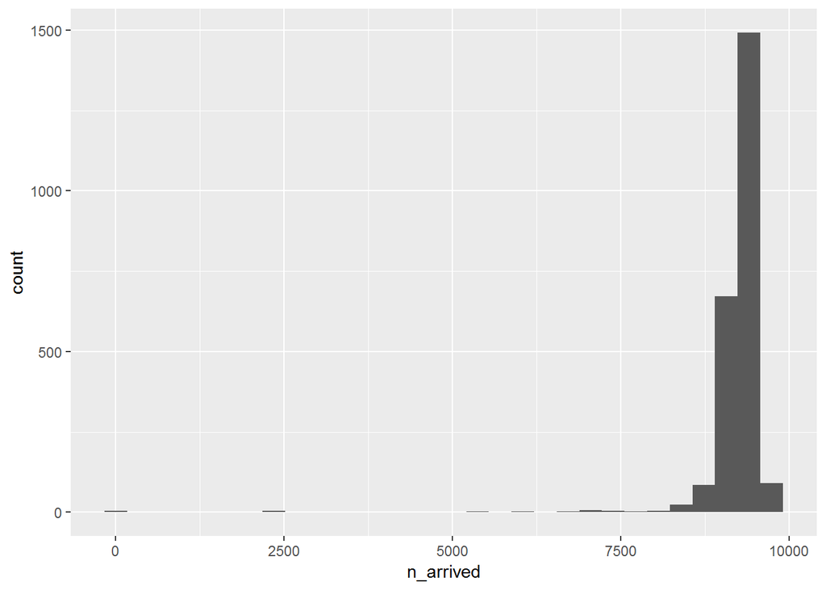

```r
ggplot(out_df, aes(x=n_arrived)) + geom_histogram()
```

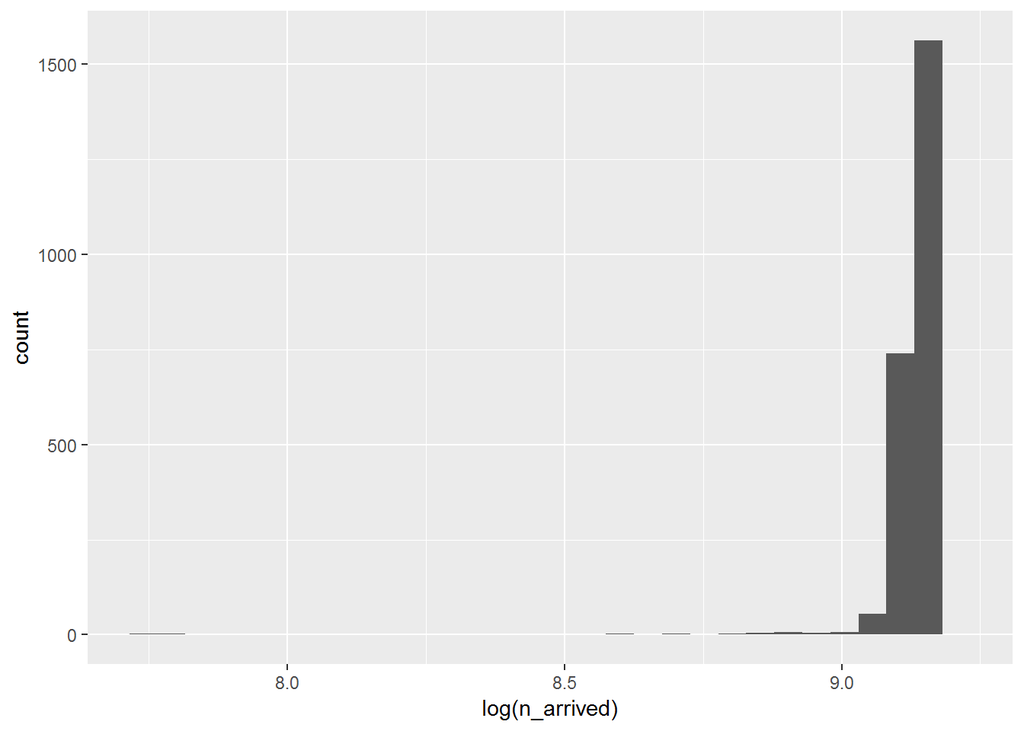

```r
ggplot(out_df, aes(x=log(n_arrived))) + geom_histogram()
```

There’s one point with no arrivals that looks a bit dodgy! Let’s exclude it.

```r
out_df %>% filter(n_arrived==0)
```

[output not shown]

```r
out_df %<>% filter(n_arrived!=0)
```

Plot them all to get an idea of the within/between variation.

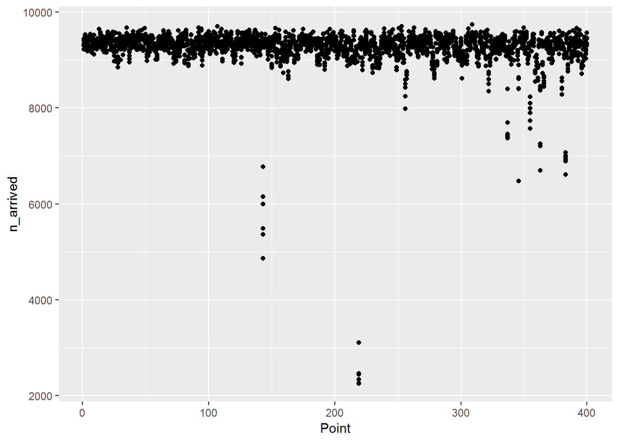

```r
ggplot(out_df, aes(x=Point,y=n_arrived)) + geom_point()
```

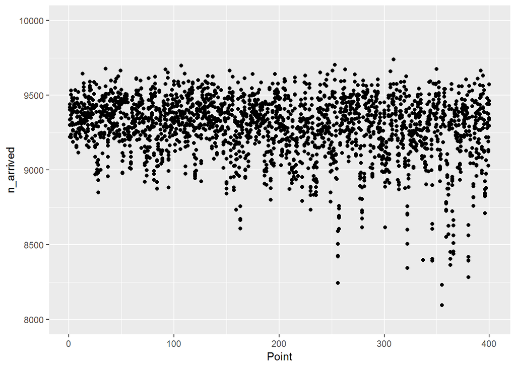

```r
ggplot(out_df, aes(x=Point,y=n_arrived)) + geom_point() + ylim(8000,10000)
```

Crude anova…

```r
arrived_av <- aov(n_arrived~as.factor(Point), out_df)
summary(arrived_av)
```

```
##                    Df    Sum Sq Mean Sq F value Pr(>F)
## as.factor(Point)  398 506607559 1272883   80.99 <2e-16 ***
## Residuals        1995  31356029   15717
## ---
## Signif. codes:  0 '***' 0.001 '**' 0.01 '*' 0.05 '.' 0.1 ' ' 1
```

# Fitting a GP

I first need to rescale to lie in the unit square

Scaling to the unit cube only needs a division by the maximum, as the min is zero.

```r
out_df %<>% mutate_at(vars(one_of(varied_pars)), function(x) x/max(x))
```

Scale the outputs and take the mean and variance of *mean* output at each point.

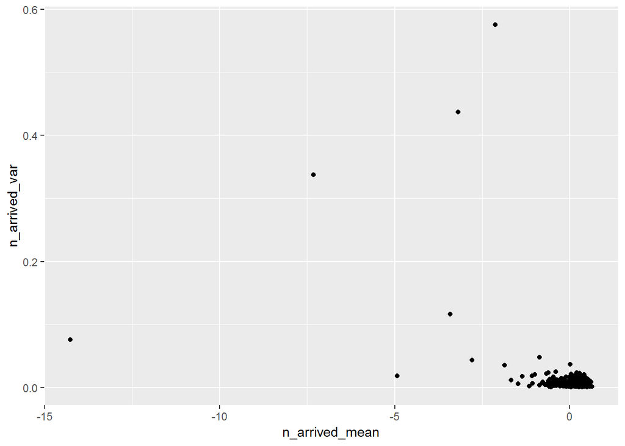

```r
out_std_df <- out_df %>% mutate_at(vars(one_of(out_pars)),
                                   function(x) (x - mean(x))/sd(x))

out_std_df %<>% group_by(Point) %>%
  summarise_at(vars(one_of(out_pars)),
               list(mean=mean,
                    var=function(x) var(x)/n()))


ggplot(out_std_df,aes(x=n_arrived_mean,
                      y=n_arrived_var)) + geom_point()
```

```r
out_std_df <- left_join(out_std_df,out_df) %>%
  filter(Repetition==1) %>% select(-one_of(out_pars), -log_det_exit_cor, -Repetition)
```

Let’s just take a look at the bivariate correlations. Which variables drive the very low values in the number arrived.

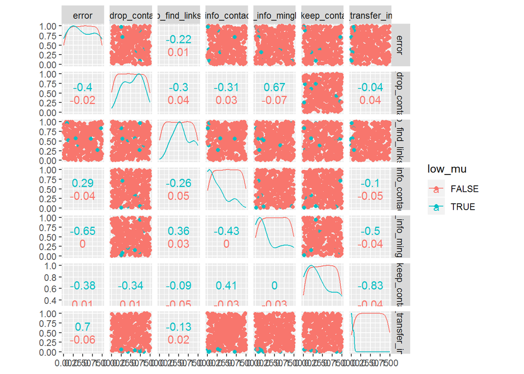

```r
GGally::ggscatmat(out_std_df %>% mutate(low_mu=as.factor(n_arrived_mean< -2)), columns=8:14, color="low_mu")
```

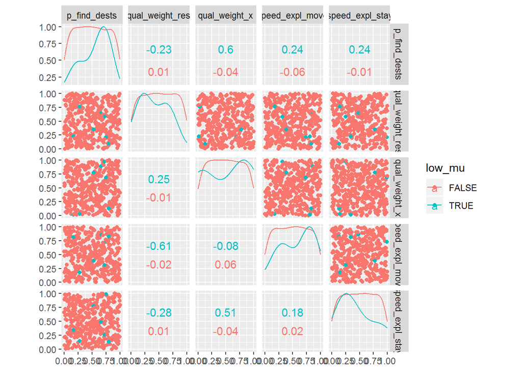

```r
GGally::ggscatmat(out_std_df %>% mutate(low_mu=as.factor(n_arrived_mean< -2)), columns=15:19, color="low_mu")
```

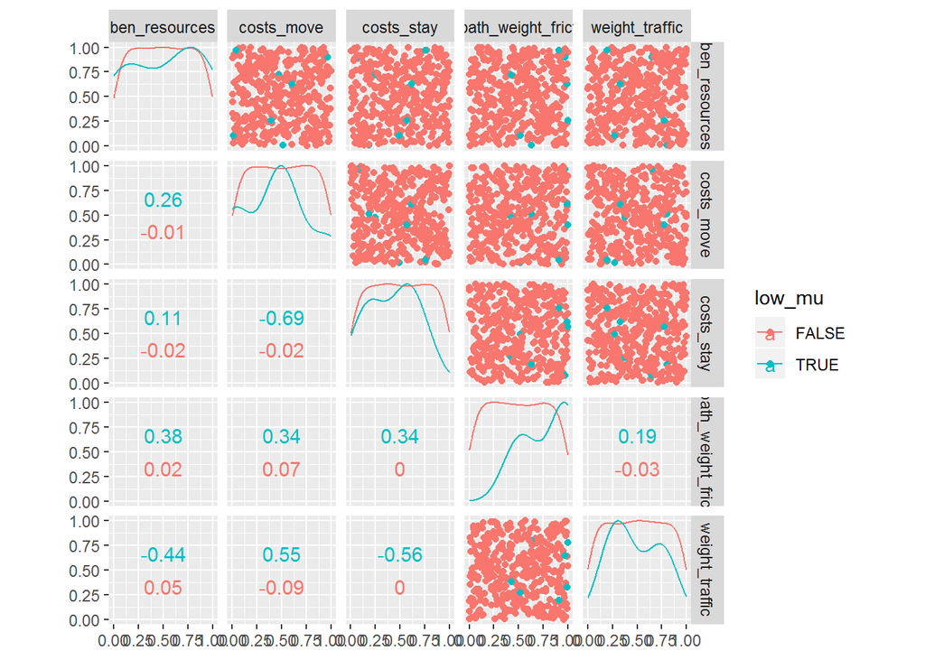

```r
GGally::ggscatmat(out_std_df %>% mutate(low_mu=as.factor(n_arrived_mean< -2)), columns=20:24, color="low_mu")
```

`p_transfer_info` seems the biggest driver.

# N arrived

Fit a gp and plot the roughness parameters. Higher = relevant.

```r
# this is a useful test of the ARD method.
# I know weight traffic was really inactive (because of my mistake in the runs)
# lets see if the ard detects this.


D <- out_std_df %>% select(one_of(varied_pars))


yy <- out_std_df$n_arrived_mean
yy_var <- out_std_df$n_arrived_var

library(doParallel)
```

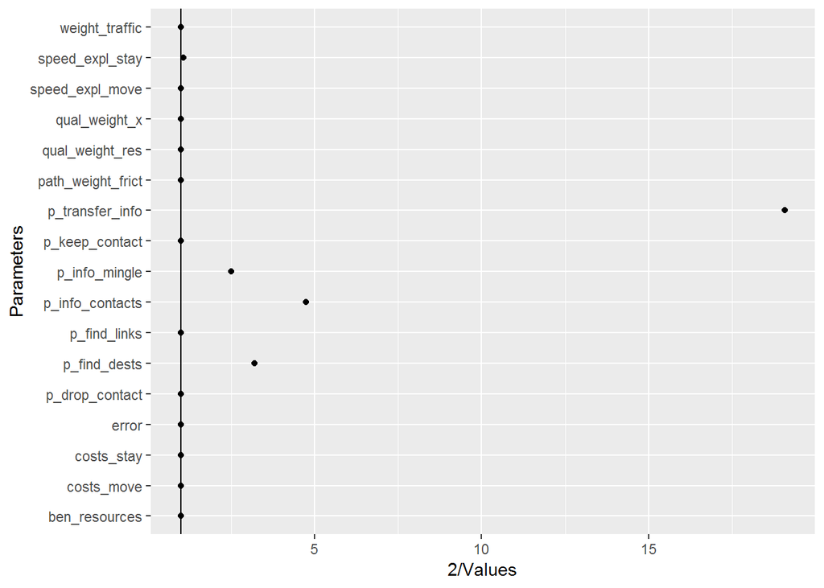

```r
library(foreach)
registerDoParallel()

mod1 <- km(response=yy, design=D, noise.var=yy_var,
           covtype = "gauss",
           multistart = 10,
           control=list(trace=F))


ARD_1 <- tibble(Parameters=names(D), Values=coef(mod1)$range)

ggplot(ARD_1,
       aes(x=Parameters, y=2/Values)) + geom_point() + coord_flip() +
  geom_hline(yintercept = 1)
```

What if we try excluding the extreme points as these look to be runs that do not reach equilibrium.

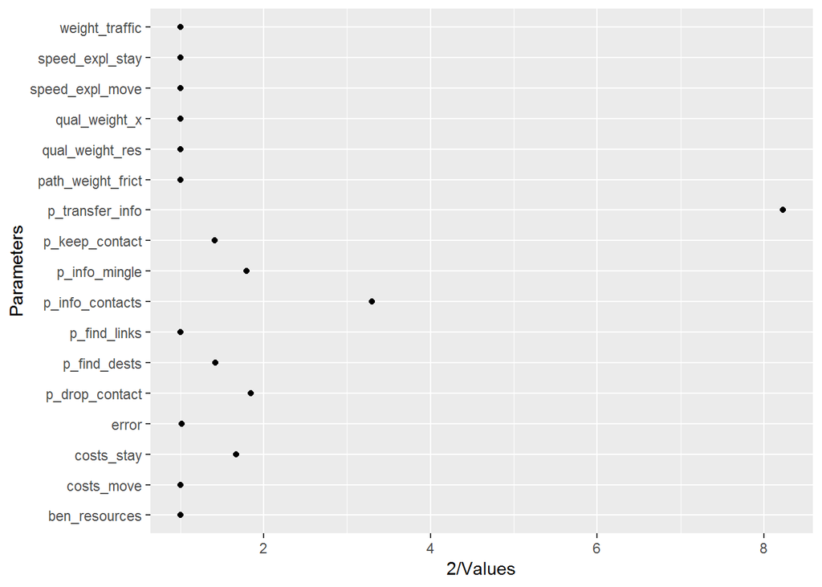

```r
out_subset_df <- out_std_df %>% filter(n_arrived_mean > -2)


D2 <-  out_subset_df %>% select(one_of(varied_pars))
yy <- out_subset_df$n_arrived_mean
yy_var <- out_subset_df$n_arrived_var

mod2 <- km(response=yy, design=D2, noise.var=yy_var,
           covtype = "gauss",
           multistart = 10,
           control=list(trace=F))


ARD_2 <- tibble(Parameters=names(D2), Values=coef(mod2)$range)

ggplot(ARD_2, aes(x=Parameters, y=2/Values)) + geom_point() + coord_flip()
```

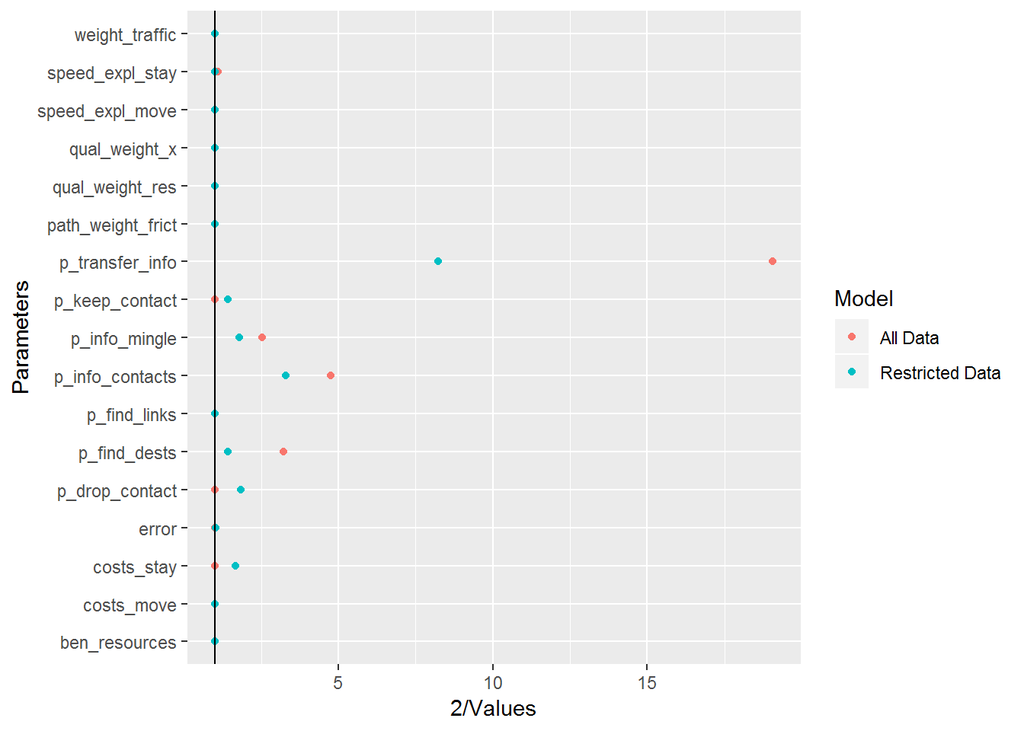

```r
ARD_both <- rbind(ARD_1 %>% mutate(Model="All Data"),
                  ARD_2 %>% mutate(Model="Restricted Data"))

ggplot(ARD_both, aes(x=Parameters, y=2/Values,
                     colour=Model)) + geom_point() + coord_flip() +
  geom_hline(yintercept = 1)
```

Final comparison - what about if we fit the model with an estimated nugget instead of supplying the empirical variance?

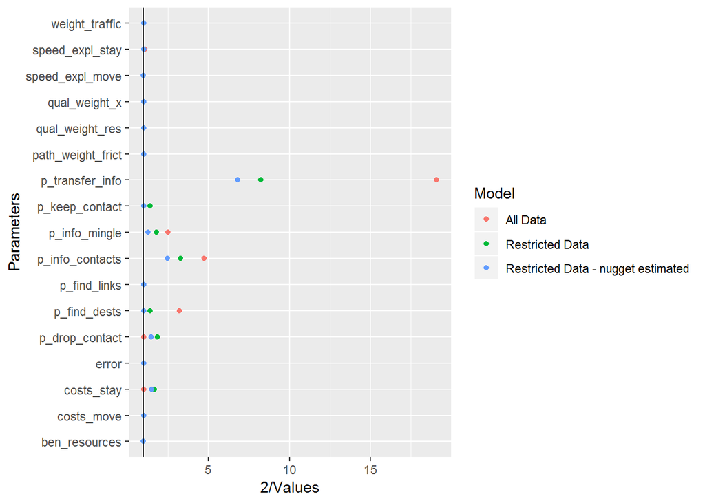

```r
mod3 <- km(response=yy, design=D2, nugget.estim = T,
           covtype = "gauss",
           multistart = 10,
           control=list(trace=F))


ARD_3 <- tibble(Parameters=names(D2), Values=coef(mod3)$range)
ARD_all <- rbind(ARD_1 %>% mutate(Model="All Data"),
                  ARD_2 %>% mutate(Model="Restricted Data"),
                  ARD_3 %>% mutate(Model="Restricted Data - nugget estimated"))

ggplot(ARD_all, aes(x=Parameters, y=2/Values,
                     colour=Model)) + geom_point() + coord_flip() +
  geom_hline(yintercept = 1)
```

Mostly the same.

This list has the ones that show some roughness/ sensitivity.

```r
ARD_all %>% group_by(Parameters) %>% filter(Values ==min(Values)) %>%
  ungroup() %>% arrange(Values) %>% filter(Values<1.99)
```

```
## # A tibble: 9 x 3
##   Parameters      Values Model
##   <chr>            <dbl> <chr>
## 1 p_transfer_info  0.105 All Data
## 2 p_info_contacts  0.422 All Data
## 3 p_find_dests     0.622 All Data
## 4 p_info_mingle    0.795 All Data
## 5 p_drop_contact   1.08  Restricted Data
## 6 costs_stay       1.20  Restricted Data
## 7 p_keep_contact   1.42  Restricted Data
## 8 speed_expl_stay  1.85  All Data
## 9 error            1.97  Restricted Data
```

# Log-entropy of distribution of cities

High entropy = all the cities get the same proportion of migrants.

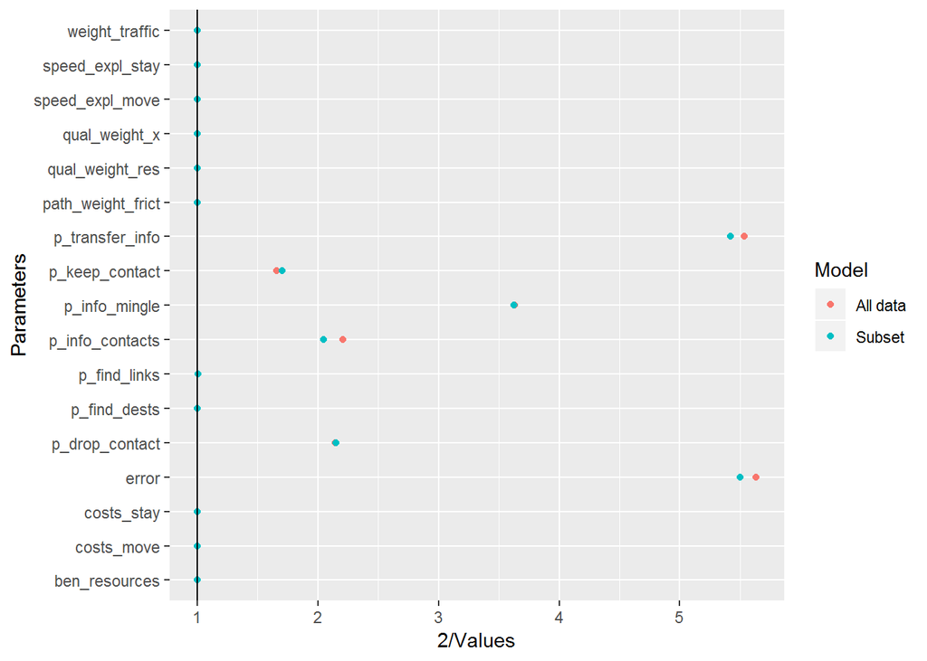

```r
yy <- out_std_df$Log_ent_count_mean
yy_var <- out_std_df$Log_ent_count_var


registerDoParallel() # sometimes the parellel thing seems to get a bit lost
mod_ent_1 <- km(response=yy, design=D, noise.var=yy_var,
                covtype = "gauss",
                multistart = 10,
                control=list(trace=F))


ARD_ent_1 <- tibble(Parameters=names(D), Values=coef(mod_ent_1)$range)


mod_ent_2 <- km(response=out_subset_df$Log_ent_count_mean,
                design=D2,
                noise.var=out_subset_df$Log_ent_count_var,
                covtype = "gauss",
                multistart = 10,
                control=list(trace=F))


ARD_ent_2 <- tibble(Parameters=names(D2), Values=coef(mod_ent_2)$range)


ARD_ent <- rbind(ARD_ent_1 %>% mutate(Model="All data"),
                 ARD_ent_2 %>% mutate(Model="Subset"))

ggplot(ARD_ent, aes(x=Parameters, y=2/Values,
                    colour=Model)) + geom_point() + coord_flip() +
  geom_hline(yintercept = 1)
```

```r
ARD_ent %>% arrange(Values)
```

```
## # A tibble: 34 x 3
##    Parameters      Values Model
##    <chr>            <dbl> <chr>
##  1 error            0.355 All data
##  2 p_transfer_info  0.361 All data
##  3 error            0.364 Subset
##  4 p_transfer_info  0.369 Subset
##  5 p_info_mingle    0.551 All data
##  6 p_info_mingle    0.551 Subset
##  7 p_info_contacts  0.907 All data
##  8 p_drop_contact   0.931 Subset
##  9 p_drop_contact   0.934 All data
## 10 p_info_contacts  0.977 Subset
## # ... with 24 more rows
```

# Mean Capital

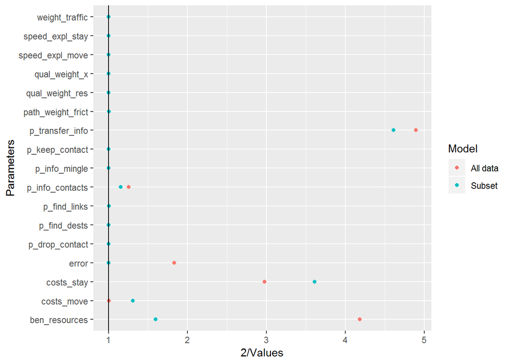

```r
yy <- out_std_df$mean_cap_mean
yy_var <- out_std_df$mean_cap_var


registerDoParallel() # sometimes the parellel thing seems to get a bit lost
mod_cap_1 <- km(response=yy, design=D, noise.var=yy_var,
                covtype = "gauss",
                multistart = 10,
                control=list(trace=F))


ARD_cap_1 <- tibble(Parameters=names(D), Values=coef(mod_cap_1)$range)

mod_cap_2 <- km(response=out_subset_df$mean_cap_mean,
                design=D2,
                noise.var=out_subset_df$mean_cap_var,
                covtype = "gauss",
                multistart = 10,
                control=list(trace=F))


ARD_cap_2 <- tibble(Parameters=names(D2), Values=coef(mod_cap_2)$range)

ARD_cap <- rbind(ARD_cap_1 %>% mutate(Model="All data"),
                 ARD_cap_2 %>% mutate(Model="Subset"))

ggplot(ARD_cap, aes(x=Parameters, y=2/Values, colour=Model)) +
  geom_point() + coord_flip() +
  geom_hline(yintercept = 1)
```

```r
ARD_cap %>% arrange(Values)
```

```
## # A tibble: 34 x 3
##    Parameters      Values Model
##    <chr>            <dbl> <chr>
##  1 p_transfer_info  0.409 All data
##  2 p_transfer_info  0.434 Subset
##  3 ben_resources    0.478 All data
##  4 costs_stay       0.554 Subset
##  5 costs_stay       0.672 All data
##  6 error            1.09  All data
##  7 ben_resources    1.25  Subset
##  8 costs_move       1.53  Subset
##  9 p_info_contacts  1.60  All data
## 10 p_info_contacts  1.74  Subset
## # ... with 24 more rows
```

# Correlations over cities

How likely is it that one city will get high proportion of migrants, given it got a high proportion in a previous repetition with the same parameters.

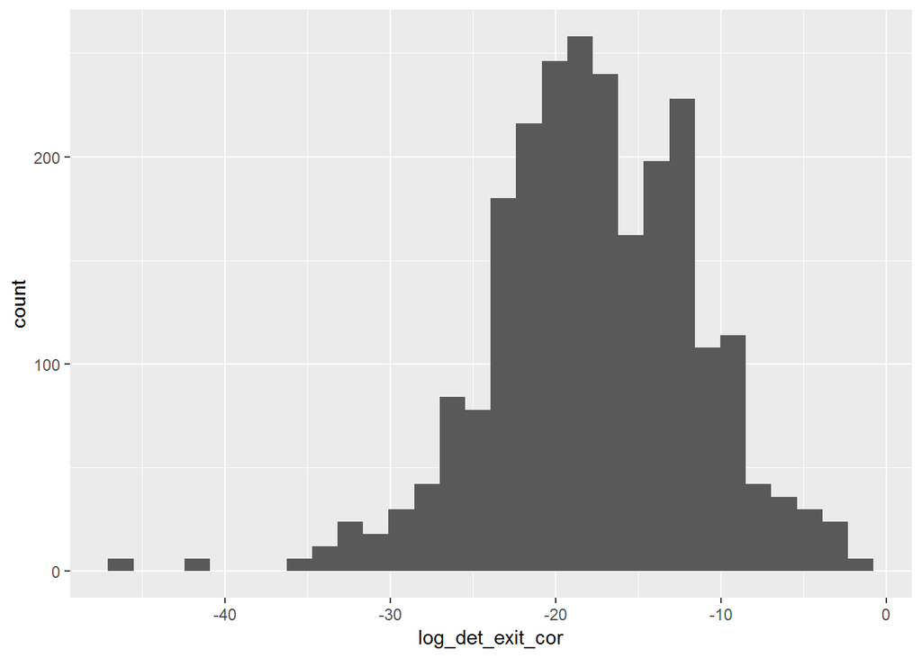

```r
ggplot(out_df,aes(x=log_det_exit_cor)) + geom_histogram()
```

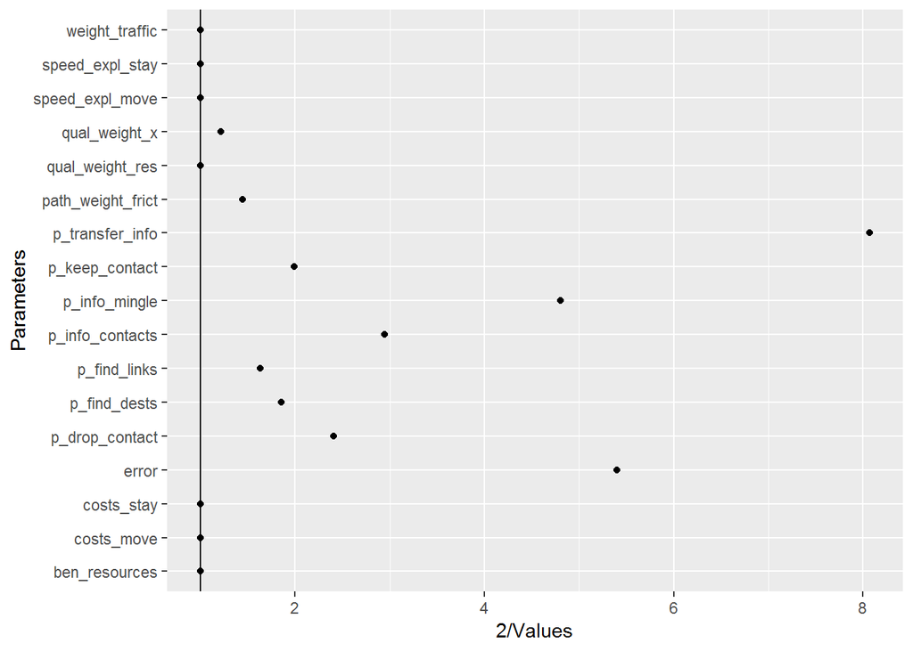

```r
log_det_df <- out_df %>% group_by(Point) %>% summarise_each(first) %>%
  ungroup() %>% arrange(Point)

yy <- log_det_df$log_det_exit_cor

yy <- (yy - mean(yy))/ sd(yy)

# put dummy weight traffic in.

D3 <- log_det_df %>% select(one_of(varied_pars))

registerDoParallel() # sometimes the parellel thing seems to get a bit lost
modA <- km(response=yy, design=D3, nugget.estim = T,
           covtype = "gauss",
           multistart = 10,
           control=list(trace=F))


ARD_det <- tibble(Parameters=varied_pars, Values=coef(modA)$range)

ggplot(ARD_det, aes(x=Parameters, y=2/Values)) + geom_point() + coord_flip() +
  geom_hline(yintercept = 1)
```

```r
ARD_det %>% arrange(Values)
```

```
## # A tibble: 17 x 2
##    Parameters        Values
##    <chr>              <dbl>
##  1 p_transfer_info    0.248
##  2 error              0.370
##  3 p_info_mingle      0.416
##  4 p_info_contacts    0.679
##  5 p_drop_contact     0.829
##  6 p_keep_contact     1.01
##  7 p_find_dests       1.08
##  8 p_find_links       1.22
##  9 path_weight_frict  1.38
## 10 qual_weight_x      1.64
## 11 costs_stay         2.00
## 12 costs_move         2.00
## 13 qual_weight_res    2.00
## 14 weight_traffic     2.00
## 15 speed_expl_stay    2.00
## 16 ben_resources      2.00
## 17 speed_expl_move    2.00
```

```r
ARD <- rbind(ARD_det %>% mutate(Output="log_det_exit_cor",
                                Model="All Data"),
             ARD_cap %>% mutate(Output="mean_cap"),
             ARD_all %>% mutate(Output="n_arrived"),
             ARD_ent %>% mutate(Output="Log_ent_count"))

saveRDS(ARD, file.path(here(),"results", paste0("ARD_", results_date,  ".rds")))
```